### Stat 135 Final Project in R

# Callin Switzer

#### Part 1

# Shiny app to “discover” relationships in animals

```r
# packages
library(shiny)
library(ggvis)
runApp("~/Desktop/S135App4")

# App with Absolute latitudes
runApp("~/Desktop/S135App5")

# deploy the app
# shinyapps::deployApp('~/Desktop/S135App4')

# show metabolic rate vs. body mass

# identify outliers
```

#### Part 2

# Why can’t you use t-tests when comparing variances?

## Here are some functions for simulations – see below for the acutal description.

```r
# Functions

# calculates the mean of a random sample
mm <- function(pop.Var = 10^2, popMean = 10, nsamples = 10){
     mean(rnorm(nsamples, popMean, sqrt(pop.Var)))
}

# returns a histogram of the sampling distribution of the sample mean, after 10,000 simulations
# plots a normal density line
samplingDistributionOfTheMean <- function(pop.Var = 10^2, popMean = 10, nsamples = 10){
     # We now calculate sample mean for 10000 random populations
     replications <- replicate(100000, mm(pop.Var, popMean, nsamples))
     hist(replications, freq = F,
          main = paste("Hist of sample mean when number of samples = ",
                       nsamples), breaks = 100, xlab = "means")

     # normal line
     grid <- seq(min(replications), to = max(replications), by = .01)

     # theoretical sampling distibution of the mean is, in this case N(0,10^2/10)
     density = dnorm(grid, mean = popMean, sqrt(pop.Var/nsamples))
     lines(x = grid, density)
     legend("topright", legend = "Theoretical Density", lty = 1)
}

# calculates the variance for a random sample
VARS <- function(nsamp = 7, pop.variance = 100){
     var(rnorm(nsamp, 010, sqrt(pop.variance)))
}

# returns a histogram of the sampling distribution of the sample variance
# plots a normal density line and a chi-squared density line
samplingDistributionOfTheVariance <- function(pop.variance = 100, popMean = 10, nsamp = 5){
     # histogram of sampling distribution
     replications <- replicate(100000, VARS(nsamp, pop.variance)*(nsamp - 1)/pop.variance)
     hist(replications, freq = F,
          main = paste("Hist of variance when number of samples = ", nsamp),
          xlab = "scaled variances", breaks = 100)

     # normal line
     grid <- seq(min(replications), to = max(replications), by = .1)

     # theoretical sampling distibution of the var is no longer normal
     density = dnorm(grid, mean(replications),sd(replications))
     lines(x = grid, density)

     # the sampling distribution of sample variance is (n-1)*S^2/(population variance) ~ ChiSq(df = n-1)
     densChi <- dchisq(grid, df = nsamp - 1)
     lines(x = grid, densChi, col = "red")
     legend("topright", legend = c("Normal Density", "Chi Squared Density"), lty = c(1,1), col = c("black", "red"))
}
```

# Sampling Distribution of the sample mean

Say we sample 30 random birds from a population, and their velocities are distributed normally, with mean = 100, and standard deviation = 10 (variance = 10^2)

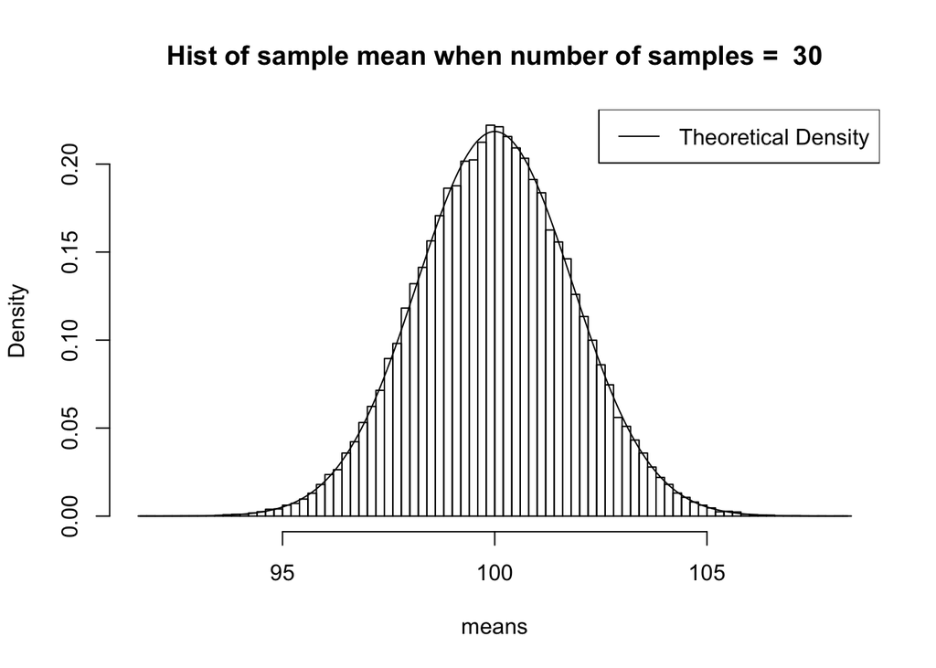

```r
samplingDistributionOfTheMean(pop.Var = 100, popMean = 100, nsamples = 30)
```

# Sampling distribution of sample variance

Now, suppose we do the same thing, but we calculate the variance for each sample, rather than the mean. This is what the (scaled) sampling distribution of the sample variance looks like. *note: this distribution is scaled, but the logic still holds*

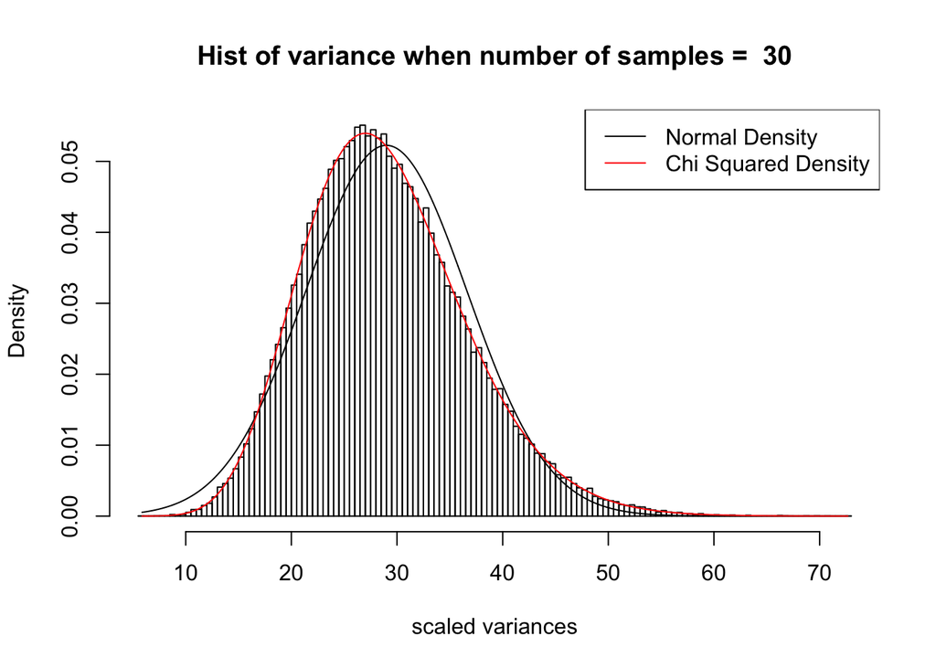

```r
samplingDistributionOfTheVariance(pop.variance = 100, popMean = 100, nsamp = 30)
```

Above, a normal approximation doesn’t fit the data as well as a chi-squared density. Furthermore, the normall approximation gets really bad as the number of samples decreases. Below is an instance where we sample only 10 birds and calculate their variances. The sampling distribution of variance is very skewed.

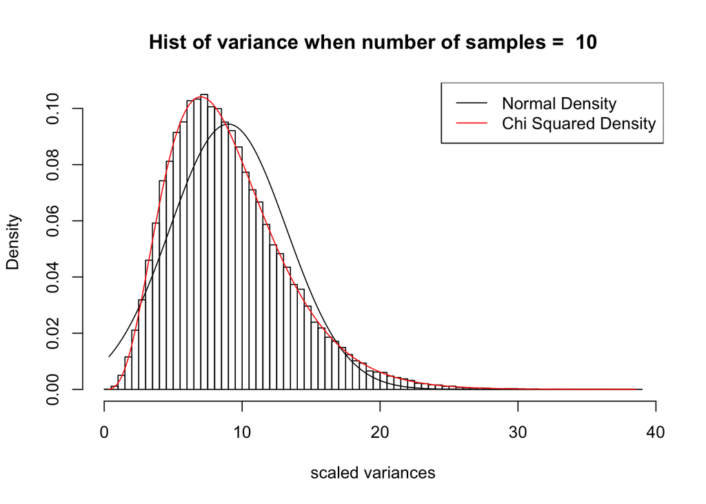

```r
samplingDistributionOfTheVariance(pop.variance = 100, popMean = 100, nsamp = 10)
```

This is why t-tests are inappropriate for testing variance….unless your samples get really large (in which case the chi-squared and normal curves are basically the same – see below for a sample size of 500)

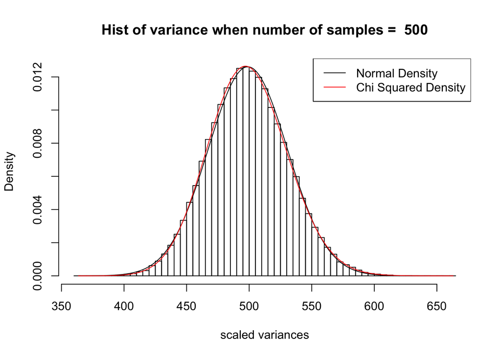

```r
samplingDistributionOfTheVariance(pop.variance = 100, popMean = 100, nsamp = 500)
```